# Introduction to Analytics Course Project

#### Group Name: Ne Ne Chicken

#### Group Members:

- 1.Siyu Li s3673512
- 2.Yuxuan Tian s3679557
- 3.Yulun Wang s3691235
- 4.MingYang Wang s3632157
- 5.Xuan Ye s3586968

## Introduction

Wine certification is generally assessed by physicochemical and sensory tests . Physicochemical laboratory tests routinely used to characterize wine include determination of density, alcohol or pH values, while sensory tests rely mainly on human experts. It should be stressed that taste is the least understood of the human senses thus wine classification is a difficult task. Moreover, There are numerous factors that may impact the quality of red wine and white wine.so it will be a gigantic challenge to Find the biggest contributors.

This report is organized as follows:

- Overview section describes the dataset used and the features in this dataset.
- Data Preparation section covers data cleaning and data preparation steps.
- Data Exploration section explores dataset features and their inter-relationships.
- Statistical Modeling and Performance Evaluation section fits multiple linear regression models and performs diagnostic checks.
- Summary and Conclusions section provides a summary of our methodology and presents our findings.
- Reference

## Data source

For this project,the datasets that we choose are from the UCI Machine Learning Repository which concatenate two datasets'winequality-white.csv`and`winequality-red.csv` into one. Those datasets are provided to test more computationally demanding machine learning algorithms that is useful for our goal. It has been selected from Wine Quality Data Set(at https://archive.ics.uci.edu/ml/datasets/Wine+Quality) by Paulo Cortez,António Cerdeira, Fernando Almeida,Telmo Matos,José Reis. Data repository available on the https://www.sciencedirect.com/science/article/pii/S0167923609001377?via%3Dihub (November 2009)

## Project Objective

Our aim is to determine which physicochemical input have the most impact on quality of wine, being affected positively or negatively in what degree.We analyse by selected variables due to various factors to see which one has the main effect on wine.

## Response variable

Output variable (based on sensory data):

- **`quality`** (score between 0 and 10)

We choose the only output quality as our response /target feature. It is a numerical integer which is able to be set as the actual quality that built up graphs and linear regression models for comparison with those 11 descriptive features. Quality of wine: quality measure in wine

## Descriptive Features

- **`fixed acidity`**
- **`volatile acidity`**
- **`citric acid`**
- **`residual sugar`**
- **`chlorides`**
- **`free sulfur dioxide`**
- **`total sulfur dioxide`**
- **`density`**
- **`pH`**
- **`sulphates`**
- **`alcohol`**

# Data Preparation

```python
#First,import all modules we need to use later.
import numpy as np
import pandas as pd
import matplotlib.pyplot as plt
import seaborn as sns
import statsmodels.api as sm
import statsmodels.formula.api as smf
import warnings
import patsy
import scipy.stats as sp
from sklearn.linear_model import LinearRegression
###
warnings.filterwarnings('ignore')
###
%matplotlib inline
%config InlineBackend.figure_format = 'retina'
plt.style.use("ggplot")
```

The datasets directly read from the `winequality-white.csv`and `winequality-red.csv` which both used seprator ;' to isolate each attributes in the csv file.Then concatenate two datesets into one.

```python
#specifying the attribute names
attributeNames = [
   'fixed acidity',
   'volatile acidity',
   'citric acid',
   'residual sugar',
   'chlorides',
   'free sulfur dioxide',
   'total sulfur dioxide',
   'density',
   'pH',
   'sulphates',
   'alcohol',
   'quality',

]
#Read in data
winequality_white = pd.read_csv('winequality-white.csv',sep=';',names = attributeNames)
winequality_red = pd.read_csv('winequality-red.csv',sep=';',names = attributeNames)

#Join the two datasets together
winequality = pd.concat([winequality_white,winequality_red])

#Display randomly selected 10 rows
winequality.sample(10,random_state=999)
```

|  | fixed acidity | volatile acidity | citric acid | residual sugar | chlorides | free sulfur dioxide | total sulfur dioxide | density | pH | sulphates | alcohol | quality |
| --- | --- | --- | --- | --- | --- | --- | --- | --- | --- | --- | --- | --- |
| 1463 | 6.8 | 0.64 | 0.03 | 2.3 | 0.075 | 14 | 31 | 0.99545 | 3.36 | 0.58 | 10.4 | 6 |
| 4192 | 7.8 | 0.27 | 0.35 | 1.2 | 0.05 | 36 | 140 | 0.99138 | 3.09 | 0.45 | 11.2 | 5 |
| 2580 | 6.4 | 0.28 | 0.56 | 1.7 | 0.156 | 49 | 106 | 0.99354 | 3.1 | 0.37 | 9.2 | 6 |
| 1743 | 6.3 | 0.25 | 0.23 | 14.9 | 0.039 | 47 | 142 | 0.99705 | 3.14 | 0.35 | 9.7 | 6 |
| 4439 | 6.1 | 0.21 | 0.19 | 1.4 | 0.046 | 51 | 131 | 0.99184 | 3.22 | 0.39 | 10.5 | 5 |
| 139 | 6.8 | 0.19 | 0.36 | 1.9 | 0.035 | 30 | 96 | 0.9917 | 3.15 | 0.54 | 10.8 | 7 |
| 3599 | 5.8 | 0.2 | 0.24 | 1.4 | 0.033 | 65 | 169 | 0.99043 | 3.59 | 0.56 | 12.3 | 7 |
| 1912 | 7.1 | 0.18 | 0.26 | 1.3 | 0.041 | 20 | 71 | 0.9926 | 3.04 | 0.74 | 9.9 | 6 |
| 1065 | 8.1 | 0.26 | 0.37 | 1.9 | 0.072 | 48 | 159 | 0.9949 | 3.37 | 0.7 | 10.9 | 6 |
| 1859 | 8.9 | 0.33 | 0.34 | 1.4 | 0.056 | 14 | 171 | 0.9946 | 3.13 | 0.47 | 9.7 | 5 |

```python
# convert type "object" to "numerical"
winequality=winequality.convert_objects(convert_numeric=True)
winequality=winequality.dropna(axis=0,how='any')
print(f'Shape of the dataset is {winequality.shape}\n')
print(f"Data types are below where object indicates a string type: ")
print(winequality.dtypes) #list datatype
```

```
Shape of the dataset is (6497, 12)

Data types are below where object indicates a string type:
fixed acidity           float64
volatile acidity        float64
citric acid             float64
residual sugar          float64
chlorides               float64
free sulfur dioxide     float64
total sulfur dioxide    float64
density                 float64
pH                      float64
sulphates               float64
alcohol                 float64
quality                 float64
dtype: object
```

## Data Cleaning and Transformation

Confirm the feature types matches the description outlined in the repository#

## Checking Missing Value

```python
print(f"\nNumber of missing values for each feature:")
print(winequality.isnull().sum())
```

```
Number of missing values for each feature:
fixed acidity           0
volatile acidity        0
citric acid             0
residual sugar          0
chlorides               0
free sulfur dioxide     0
total sulfur dioxide    0
density                 0
pH                      0
sulphates               0
alcohol                 0
quality                 0
dtype: int64
```

In the concatenated datasets, no attribute contains `NaN` value. Then we need to check whether there are outliers exist.

```python
#numerical data
y = winequality['fixed acidity']
y
```

```
1       7.0
2       6.3
3       8.1
4       7.2
5       7.2
6       8.1
7       6.2
8       7.0
9       6.3
10      8.1
11      8.1
12      8.6
13      7.9
14      6.6
15      8.3
```

[output cut: 47 more lines]

```python
#maximum value of column "fixed acidity"
winequality['fixed acidity'].max()
```

```
15.9
```

```python
#minimum value of column "fixed acidity"
winequality['fixed acidity'].min()
```

```
3.8
```

```python
#mean value of column "fixed acidity"
winequality['fixed acidity'].mean()
```

```
7.2153070647991235
```

```python
#numerical data
y = winequality['volatile acidity']
y
```

```
1       0.270
2       0.300
3       0.280
4       0.230
5       0.230
6       0.280
7       0.320
8       0.270
9       0.300
10      0.220
11      0.270
12      0.230
13      0.180
14      0.160
15      0.420
```

[output cut: 47 more lines]

```python
#maximum value of column "volatile acidity"
winequality['volatile acidity'].max()
```

```
1.58
```

```python
#minimum value of column "volatile acidity"
winequality['volatile acidity'].min()
```

```
0.08
```

```python
#mean value of column "volatile acidity"
winequality['volatile acidity'].mean()
```

```
0.3396659996921661
```

```python
#numerical data
y = winequality['citric acid']
y
```

```
1       0.36
2       0.34
3       0.40
4       0.32
5       0.32
6       0.40
7       0.16
8       0.36
9       0.34
10      0.43
11      0.41
12      0.40
13      0.37
14      0.40
15      0.62
```

[output cut: 47 more lines]

```python
#maximum value of column "citric acid"
winequality['citric acid'].max()
```

```
1.66
```

```python
#minimum value of column "citric acid"
winequality['citric acid'].min()
```

```
0.0
```

```python
#mean value of column "citric acid"
winequality['citric acid'].mean(0)
```

```
0.31863321533014705
```

```python
#numerical data
y = winequality['residual sugar']
y
```

```
1       20.70
2        1.60
3        6.90
4        8.50
5        8.50
6        6.90
7        7.00
8       20.70
9        1.60
10       1.50
11       1.45
12       4.20
13       1.20
14       1.50
15      19.25
```

[output cut: 47 more lines]

```python
#maximum value of column "residual sugar"
winequality['residual sugar'].max()
```

```
65.8
```

```python
#minimum value of column "residual sugar"
winequality['residual sugar'].min
```

[output not shown]

[output cut: 47 more lines]

```python
#mean value of column "residual sugar"
winequality['residual sugar'].mean()
```

```
5.443235339387428
```

```python
#numerical data
y = winequality['chlorides']
y
```

```
1       0.045
2       0.049
3       0.050
4       0.058
5       0.058
6       0.050
7       0.045
8       0.045
9       0.049
10      0.044
11      0.033
12      0.035
13      0.040
14      0.044
15      0.040
```

[output cut: 47 more lines]

```python
#maximum value of column "chlorides"
winequality['chlorides'].max()
```

```
0.611
```

```python
#minimum value of column "chlorides"
winequality['chlorides'].min()
```

```
0.009000000000000001
```

```python
#mean value of column "chlorides"
winequality['chlorides'].mean()
```

```
0.05603386178236132
```

```python
#numerical data
y = winequality['free sulfur dioxide']
y
```

```
1       45.0
2       14.0
3       30.0
4       47.0
5       47.0
6       30.0
7       30.0
8       45.0
9       14.0
10      28.0
11      11.0
12      17.0
13      16.0
14      48.0
15      41.0
```

[output cut: 47 more lines]

```python
#maximum value of column "ree sulfur dioxide"
winequality['free sulfur dioxide'].max()
```

```
289.0
```

```python
#minimum value of column "ree sulfur dioxide"
winequality['free sulfur dioxide'].min()
```

```
1.0
```

```python
#mean value of column "ree sulfur dioxide"
winequality['free sulfur dioxide'].mean()
```

```
30.525319378174544
```

```python
#numerical data
y = winequality['total sulfur dioxide']
y
```

```
1       170.0
2       132.0
3        97.0
4       186.0
5       186.0
6        97.0
7       136.0
8       170.0
9       132.0
10      129.0
11       63.0
12      109.0
13       75.0
14      143.0
15      172.0
```

[output cut: 47 more lines]

```python
#maximum value of column "total sulfur dioxide"
winequality['total sulfur dioxide'].max()
```

```
440.0
```

```python
#minimum value of column "total sulfur dioxide"
winequality['total sulfur dioxide'].min()
```

```
6.0
```

```python
#mean value of column "total sulfur dioxide"
winequality['total sulfur dioxide'].mean()
```

```
115.7445744189626
```

```python
#numerical data
y = winequality['density']
y
```

```
1       1.00100
2       0.99400
3       0.99510
4       0.99560
5       0.99560
6       0.99510
7       0.99490
8       1.00100
9       0.99400
10      0.99380
11      0.99080
12      0.99470
13      0.99200
14      0.99120
15      1.00020
```

[output cut: 47 more lines]

```python
#maximum value of column "density"
winequality['density'].max()
```

```
1.03898
```

```python
#minimum value of column "density"
winequality['density'].min()
```

```
0.98711
```

```python
#mean value of column "density"
winequality['density'].mean()
```

```
0.9946966338309937
```

```python
#numerical data
y = winequality['pH']
y
```

```
1       3.00
2       3.30
3       3.26
4       3.19
5       3.19
6       3.26
7       3.18
8       3.00
9       3.30
10      3.22
11      2.99
12      3.14
13      3.18
14      3.54
15      2.98
```

[output cut: 47 more lines]

```python
#maximum value of column "pH"
winequality['pH'].max()
```

```
4.01
```

```python
#minimum value  of column "pH"
winequality['pH'].min()
```

```
2.72
```

```python
#mean value  of column "pH"
winequality['pH'].mean()
```

```
3.218500846544555
```

```python
#numerical data
y = winequality['sulphates']
y
```

```
1       0.45
2       0.49
3       0.44
4       0.40
5       0.40
6       0.44
7       0.47
8       0.45
9       0.49
10      0.45
11      0.56
12      0.53
13      0.63
14      0.52
15      0.67
```

[output cut: 47 more lines]

```python
#maximum value of column "sulphates"
winequality['sulphates'].max()
```

```
2.0
```

```python
#minimum value of column "sulphates"
winequality['sulphates'].min(0)
```

```
0.22
```

```python
#mean value of column "sulphates"
winequality['sulphates'].mean()
```

```
0.5312682776666168
```

```python
#numerical data
y = winequality['alcohol']
y
```

```
1        8.8
2        9.5
3       10.1
4        9.9
5        9.9
6       10.1
7        9.6
8        8.8
9        9.5
10      11.0
11      12.0
12       9.7
13      10.8
14      12.4
15       9.7
```

[output cut: 47 more lines]

```python
#maximum value of column "alcohol"
winequality['alcohol'].max()
```

```
14.9
```

```python
#minimum value of column "alcohol"
winequality['alcohol'].min()
```

```
8.0
```

```python
#mean value of column "alcohol"
winequality['alcohol'].mean()
```

```
10.491800831152897
```

```python
#numerical data
y = winequality['quality']
y
```

```
1       6.0
2       6.0
3       6.0
4       6.0
5       6.0
6       6.0
7       6.0
8       6.0
9       6.0
10      6.0
11      5.0
12      5.0
13      5.0
14      7.0
15      5.0
```

[output cut: 47 more lines]

```python
#maximum value of column "quality"
winequality['quality'].max()
```

```
9.0
```

```python
#minimum value of column "quality"
winequality['quality'].min()
```

```
3.0
```

```python
#mean value of column "quality"
winequality['quality'].mean()
```

```
5.818377712790519
```

### Summary Statistics

```python
from IPython.display import display, HTML
display(HTML('<b>Table 1: Summary of continuous features</b>'))
winequality.describe(include='float64')
```

**Table 1: Summary of continuous features**

|  | fixed acidity | volatile acidity | citric acid | residual sugar | chlorides | free sulfur dioxide | total sulfur dioxide | density | pH | sulphates | alcohol | quality |
| --- | --- | --- | --- | --- | --- | --- | --- | --- | --- | --- | --- | --- |
| count | 6497.000000 | 6497.000000 | 6497.000000 | 6497.000000 | 6497.000000 | 6497.000000 | 6497.000000 | 6497.000000 | 6497.000000 | 6497.000000 | 6497.000000 | 6497.000000 |
| mean | 7.215307 | 0.339666 | 0.318633 | 5.443235 | 0.056034 | 30.525319 | 115.744574 | 0.994697 | 3.218501 | 0.531268 | 10.491801 | 5.818378 |
| std | 1.296434 | 0.164636 | 0.145318 | 4.757804 | 0.035034 | 17.749400 | 56.521855 | 0.002999 | 0.160787 | 0.148806 | 1.192712 | 0.873255 |
| min | 3.800000 | 0.080000 | 0.000000 | 0.600000 | 0.009000 | 1.000000 | 6.000000 | 0.987110 | 2.720000 | 0.220000 | 8.000000 | 3.000000 |
| 25% | 6.400000 | 0.230000 | 0.250000 | 1.800000 | 0.038000 | 17.000000 | 77.000000 | 0.992340 | 3.110000 | 0.430000 | 9.500000 | 5.000000 |
| 50% | 7.000000 | 0.290000 | 0.310000 | 3.000000 | 0.047000 | 29.000000 | 118.000000 | 0.994890 | 3.210000 | 0.510000 | 10.300000 | 6.000000 |
| 75% | 7.700000 | 0.400000 | 0.390000 | 8.100000 | 0.065000 | 41.000000 | 156.000000 | 0.996990 | 3.320000 | 0.600000 | 11.300000 | 6.000000 |
| max | 15.900000 | 1.580000 | 1.660000 | 65.800000 | 0.611000 | 289.000000 | 440.000000 | 1.038980 | 4.010000 | 2.000000 | 14.900000 | 9.000000 |

### Fixing Column Names

Some column names contain a space, which can be problematic when modeling. Basically, when we write the regression formula. So, we modify the column names so that the space are replaced with an underscore sign.

```python
winequality.rename(columns={'fixed acidity':'fixed_acidity',
                        'volatile acidity':'volatile_aciditys',
                        'citric acid':'citric_acid',
                        'residual sugar':'residual_sugar',
                           'free sulfur dioxide':'free_sulfur_dioxide',
                           'total sulfur dioxide':'total_sulfur_dioxide'}, inplace = True)
winequality.head()
```

|  | fixed_acidity | volatile_aciditys | citric_acid | residual_sugar | chlorides | free_sulfur_dioxide | total_sulfur_dioxide | density | pH | sulphates | alcohol | quality |
| --- | --- | --- | --- | --- | --- | --- | --- | --- | --- | --- | --- | --- |
| 1 | 7.0 | 0.27 | 0.36 | 20.7 | 0.045 | 45.0 | 170.0 | 1.0010 | 3.00 | 0.45 | 8.8 | 6.0 |
| 2 | 6.3 | 0.30 | 0.34 | 1.6 | 0.049 | 14.0 | 132.0 | 0.9940 | 3.30 | 0.49 | 9.5 | 6.0 |
| 3 | 8.1 | 0.28 | 0.40 | 6.9 | 0.050 | 30.0 | 97.0 | 0.9951 | 3.26 | 0.44 | 10.1 | 6.0 |
| 4 | 7.2 | 0.23 | 0.32 | 8.5 | 0.058 | 47.0 | 186.0 | 0.9956 | 3.19 | 0.40 | 9.9 | 6.0 |
| 5 | 7.2 | 0.23 | 0.32 | 8.5 | 0.058 | 47.0 | 186.0 | 0.9956 | 3.19 | 0.40 | 9.9 | 6.0 |

# Data Exploration

The dataset can be considered "clean" after preparation. Now it is ready for exploration whatever in single or comparison way as well as statistical modeling

## Single Visualisation

Histogram, box plot, density plot, scatterplot and hexbin scatterplot of each relevant attributes

### Figure 1 : Box Plot of Alcohol

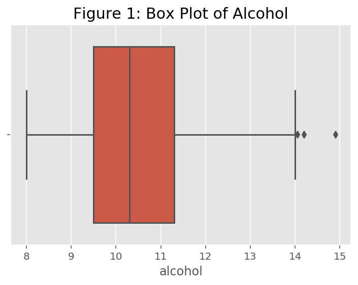

```python
sns.boxplot(winequality['alcohol']).set_title('Figure 1: Box Plot of Alcohol',fontsize = 15)
plt.show();
```

Figure 1 shows that the data of alcohol mostly between 9.5 - 11.3.

### Figure 2 : Histogram of Quality

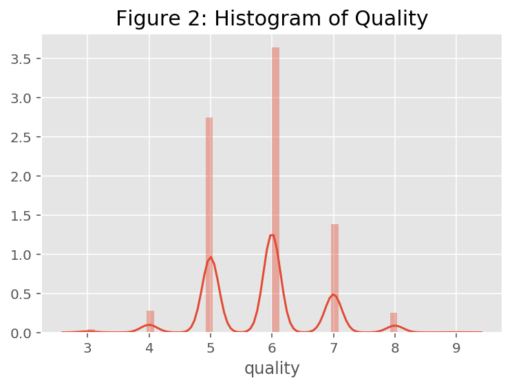

```python
sns.distplot(winequality['quality'], kde = True).set_title('Figure 2: Histogram of Quality', fontsize = 15)
plt.show();
```

### Figure 3 : Density plot of residual sugar

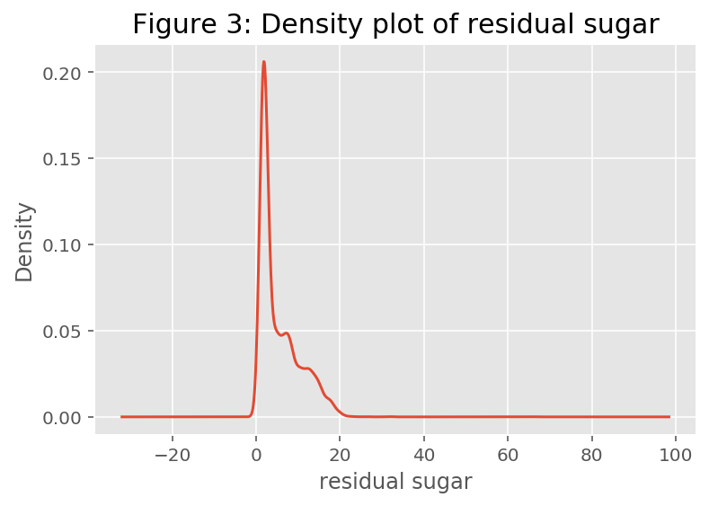

```python
winequality['residual_sugar'].plot(kind='density')
plt.title('Figure 3: Density plot of residual sugar', fontsize = 15)
plt.xlabel('residual sugar')
plt.show();
```

## Multivariate Visualisation (comparison)

### Figure 4 : Scatterplot of quality and alcohol

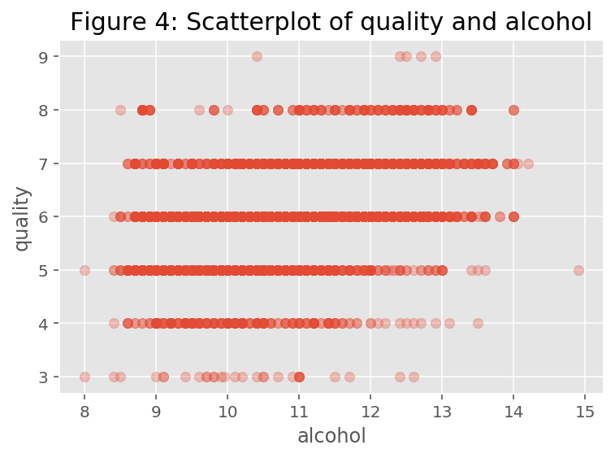

```python
plt.scatter(winequality['alcohol'], winequality['quality'], alpha = 0.3)
plt.title('Figure 4: Scatterplot of quality and alcohol', fontsize = 15)
plt.xlabel('alcohol')
plt.ylabel('quality')
plt.show();
```

The figure 4 shows the quality and alcohol. The mainly quality is between 3 and 8, and 8 - 14 in the alcohol .

### Figure 5 : Scatterplot of quality and citric acid

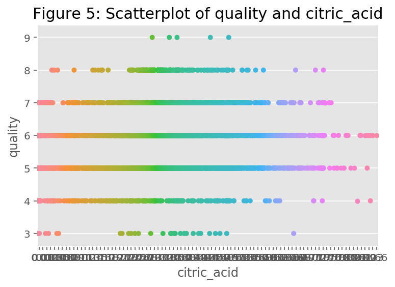

```python
sns.stripplot(x="citric_acid",y="quality",data=winequality,jitter=0.5)
plt.title('Figure 5: Scatterplot of quality and citric_acid', fontsize = 15)
plt.show()
```

The figure 5 shows the scatterplot of quality ranged from 3-8 affected by citric_acid.

### Figure 6 : Scatterplot of quality and pH

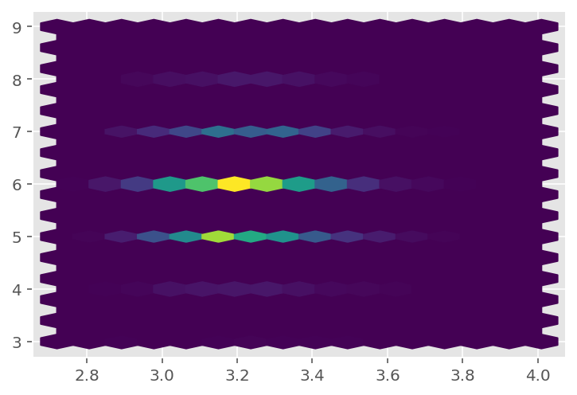

```python
plt.hexbin(winequality['pH'], winequality['quality'], gridsize=(15,15))
plt.show()
```

The figure 6 shows pH between 3.0-3.4 takes up the most in quality which is ranged from 5-7.

### Figure 7 : Scatterplot of quality and chlorides

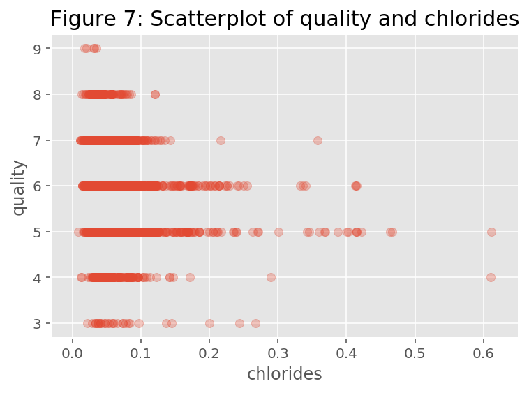

```python
plt.scatter(winequality['chlorides'], winequality['quality'], alpha = 0.3)
plt.title('Figure 7: Scatterplot of quality and chlorides', fontsize = 15)
plt.xlabel('chlorides')
plt.ylabel('quality')
plt.show();
```

The figure 7 shows quality between 3-9 mainly affected by chlorides which ranged from 0.25.

### Percentile

Median,Q1,Q3,IQR,Min,Max

```python
Median = winequality['quality'].median()
Q1 = winequality['quality'].quantile(0.25)
Q3 = round(winequality['quality'].quantile(0.75),1)
IQR = round(Q3 - Q1,1)
Min = round(winequality['quality'].min(),1)
Max = round(winequality['quality'].max(),1)
Outliers = round(Q1 - 1.5*IQR, 1)

print("Median = Q2 =", Median)
print("Q1 =", Q1)
print("Q3 =", Q3)
print("IQR =", IQR)
print("Min =", Min)
print("Max =", Max)
```

```
Median = Q2 = 6.0
Q1 = 5.0
Q3 = 6.0
IQR = 1.0
Min = 3.0
Max = 9.0
```

# Statistical Modeling and Performance Evaluation

# Full Model

We begin by fitting a multiple linear regression that predicts the relationship between each indenpendent variable to dependent`quality` using all of the avaliable features. We call this the full model. First let's take a quick peak at the clean data.

Models:

- quality and fixed acidity
- quality and volatile acidity
- quality and citric acid
- quality and residual sugar
- quality and chlorides
- quality and free sulfur dioxide
- quality and total sulfur dioxide
- quality and density
- quality and pH
- quality and sulphates
- quality and alcohol -quality and sum
- Full Model
- Backwards Variable Selection

```python
winequality.head()
```

|  | fixed_acidity | volatile_aciditys | citric_acid | residual_sugar | chlorides | free_sulfur_dioxide | total_sulfur_dioxide | density | pH | sulphates | alcohol | quality |
| --- | --- | --- | --- | --- | --- | --- | --- | --- | --- | --- | --- | --- |
| 1 | 7.0 | 0.27 | 0.36 | 20.7 | 0.045 | 45.0 | 170.0 | 1.0010 | 3.00 | 0.45 | 8.8 | 6.0 |
| 2 | 6.3 | 0.30 | 0.34 | 1.6 | 0.049 | 14.0 | 132.0 | 0.9940 | 3.30 | 0.49 | 9.5 | 6.0 |
| 3 | 8.1 | 0.28 | 0.40 | 6.9 | 0.050 | 30.0 | 97.0 | 0.9951 | 3.26 | 0.44 | 10.1 | 6.0 |
| 4 | 7.2 | 0.23 | 0.32 | 8.5 | 0.058 | 47.0 | 186.0 | 0.9956 | 3.19 | 0.40 | 9.9 | 6.0 |
| 5 | 7.2 | 0.23 | 0.32 | 8.5 | 0.058 | 47.0 | 186.0 | 0.9956 | 3.19 | 0.40 | 9.9 | 6.0 |

### quality and fixed acidity

```python
winequality = winequality[winequality.fixed_acidity != 0.0]
formula_string = "quality  ~ fixed_acidity "
model = sm.formula.ols(formula=formula_string, data = winequality)
model_fitted = model.fit()
print(model_fitted.summary())
```

```
                            OLS Regression Results
==============================================================================
Dep. Variable:                quality   R-squared:                       0.006
Model:                            OLS   Adj. R-squared:                  0.006
Method:                 Least Squares   F-statistic:                     38.48
Date:                Sun, 03 Nov 2019   Prob (F-statistic):           5.87e-10
Time:                        01:14:15   Log-Likelihood:                -8318.6
No. Observations:                6497   AIC:                         1.664e+04
Df Residuals:                    6495   BIC:                         1.665e+04
Df Model:                           1
Covariance Type:            nonrobust
=================================================================================
                    coef    std err          t      P>|t|      [0.025      0.975]
---------------------------------------------------------------------------------
Intercept         6.1914      0.061    101.348      0.000       6.072       6.311
fixed_acidity    -0.0517      0.008     -6.203      0.000      -0.068      -0.035
==============================================================================
Omnibus:                       49.043   Durbin-Watson:                   1.656
Prob(Omnibus):                  0.000   Jarque-Bera (JB):               51.755
Skew:                           0.188   Prob(JB):                     5.77e-12
Kurtosis:                       3.222   Cond. No.                         42.2
==============================================================================

Warnings:
[1] Standard Errors assume that the covariance matrix of the errors is correctly specified.
```

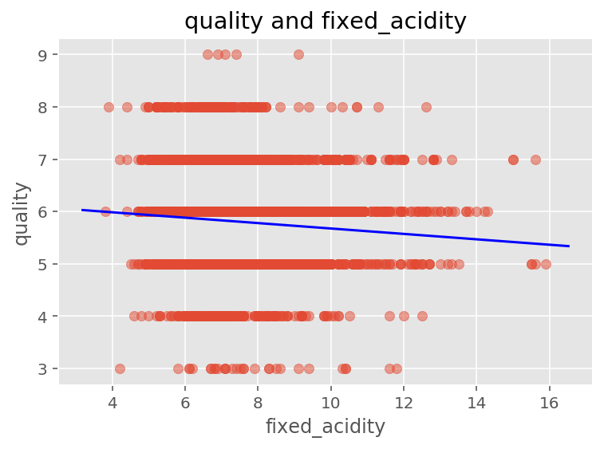

```python
def plot_line(axis, slope, intercept, **kargs):
    xmin, xmax = axis.get_xlim()
    plt.plot([xmin, xmax], [xmin*slope+intercept, xmax*slope+intercept], **kargs)


def plot_line(axis, slope, intercept, **kargs):
    xmin, xmax = axis.get_xlim()
    plt.plot([xmin, xmax], [xmin*slope+intercept, xmax*slope+intercept], **kargs)

y=winequality['fixed_acidity']
x=winequality['quality']

plt.scatter(winequality['fixed_acidity'], winequality['quality'], alpha = 0.5)
plot_line(axis = plt.gca(), slope = model_fitted.params['fixed_acidity'], intercept = model_fitted.params['Intercept'], color = 'blue')
plt.title('quality and fixed_acidity')
plt.xlabel('fixed_acidity')
plt.ylabel('quality')
plt.show()
```

We can observe that through the regression modelling, predicted quality in blue and the actual data combined with quality and fixed_acidity scattered in red, actual data near the regression line and just slightly under when quality is 6, which means that fixed-acidity affected when quality is 6 in some degress.

### Residuals

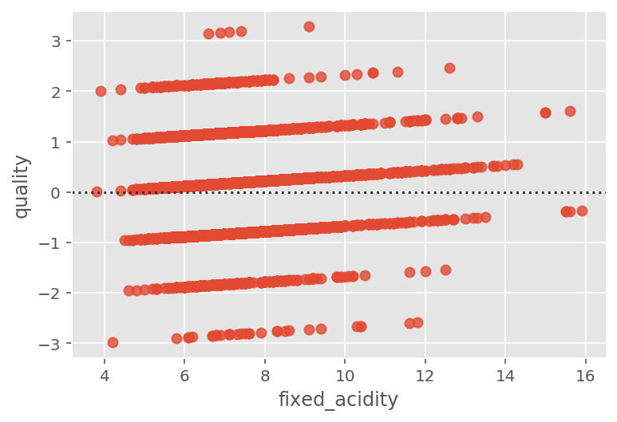

```python
sns.residplot(y, x)
plt.show()
```

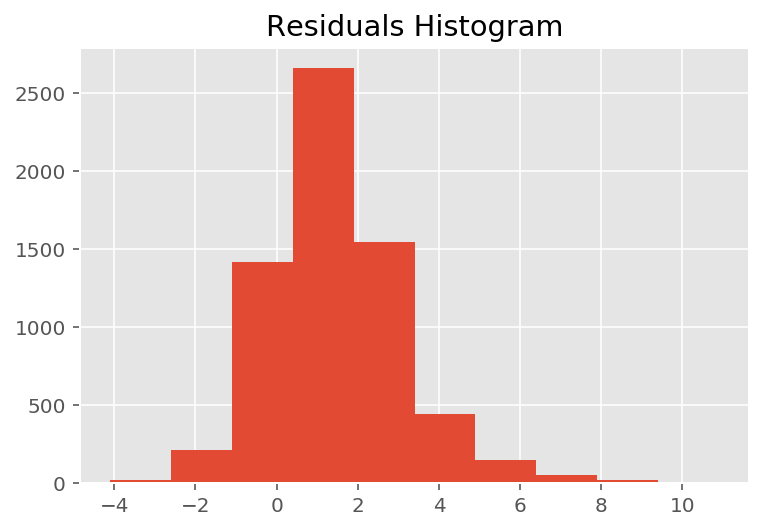

```python
residuals = y - x
plt.hist(residuals, bins = 10)
plt.title('Residuals Histogram')
plt.show()
```

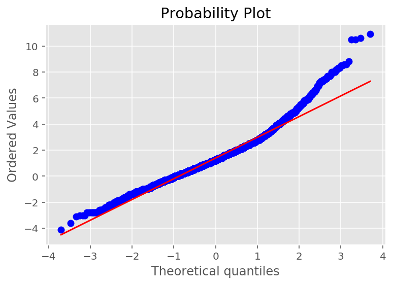

```python
sp.probplot(residuals, plot = plt)
plt.show()
```

### quality and volatile aciditys

```python
winequality = winequality[winequality.volatile_aciditys != 0.0]
formula_string = "quality ~volatile_aciditys"
model = sm.formula.ols(formula=formula_string, data = winequality)
model_fitted = model.fit()
print(model_fitted.summary())
```

```
                            OLS Regression Results
==============================================================================
Dep. Variable:                quality   R-squared:                       0.071
Model:                            OLS   Adj. R-squared:                  0.070
Method:                 Least Squares   F-statistic:                     493.4
Date:                Sun, 03 Nov 2019   Prob (F-statistic):          2.06e-105
Time:                        01:14:17   Log-Likelihood:                -8100.0
No. Observations:                6497   AIC:                         1.620e+04
Df Residuals:                    6495   BIC:                         1.622e+04
Df Model:                           1
Covariance Type:            nonrobust
=====================================================================================
                        coef    std err          t      P>|t|      [0.025      0.975]
-------------------------------------------------------------------------------------
Intercept             6.2971      0.024    262.932      0.000       6.250       6.344
volatile_aciditys    -1.4093      0.063    -22.212      0.000      -1.534      -1.285
==============================================================================
Omnibus:                       81.788   Durbin-Watson:                   1.659
Prob(Omnibus):                  0.000   Jarque-Bera (JB):               91.918
Skew:                           0.231   Prob(JB):                     1.10e-20
Kurtosis:                       3.356   Cond. No.                         6.79
==============================================================================

Warnings:
[1] Standard Errors assume that the covariance matrix of the errors is correctly specified.
```

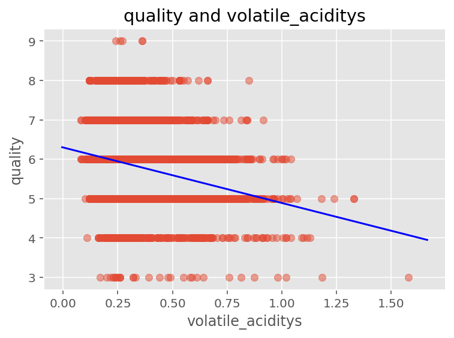

```python
def plot_line(axis, slope, intercept, **kargs):
    xmin, xmax = axis.get_xlim()
    plt.plot([xmin, xmax], [xmin*slope+intercept, xmax*slope+intercept], **kargs)


def plot_line(axis, slope, intercept, **kargs):
    xmin, xmax = axis.get_xlim()
    plt.plot([xmin, xmax], [xmin*slope+intercept, xmax*slope+intercept], **kargs)

y=winequality['volatile_aciditys']
x=winequality['quality']

plt.scatter(winequality['volatile_aciditys'], winequality['quality'], alpha = 0.5)
plot_line(axis = plt.gca(), slope = model_fitted.params['volatile_aciditys'], intercept = model_fitted.params['Intercept'], color = 'blue')
plt.title('quality and volatile_aciditys')
plt.xlabel('volatile_aciditys')
plt.ylabel('quality')
plt.show()
```

We can observe that through the regression modelling, predicted quality in blue and the actual data combined with quality and volatile_aciditys scattered in red, actual data is not very closed to the regression line and exceed a lot when quality is between 4-6, which means that volatile_aciditys not that affected when quality ranged from 4-6 in some degress.

### Residuals

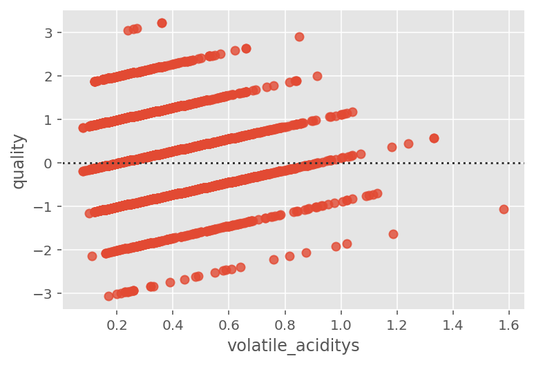

```python
sns.residplot(y, x)
plt.show()
```

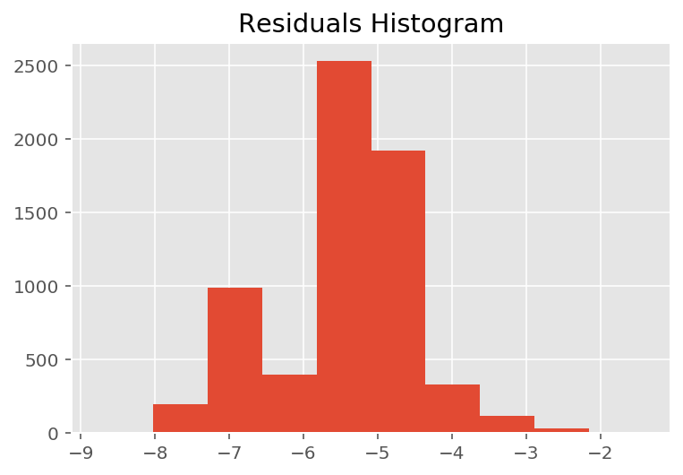

```python
residuals = y - x
plt.hist(residuals, bins = 10)
plt.title('Residuals Histogram')
plt.show()
```

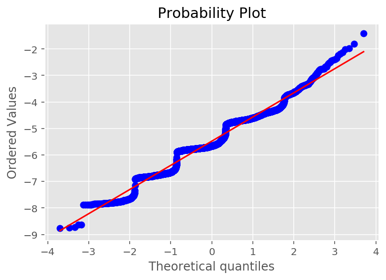

```python
sp.probplot(residuals, plot = plt)
plt.show()
```

### quality and citric acid

```python
winequality = winequality[winequality.citric_acid != 0.0]
formula_string = "quality ~citric_acid"
model = sm.formula.ols(formula=formula_string, data = winequality)
model_fitted = model.fit()
print(model_fitted.summary())
```

```
                            OLS Regression Results
==============================================================================
Dep. Variable:                quality   R-squared:                       0.004
Model:                            OLS   Adj. R-squared:                  0.004
Method:                 Least Squares   F-statistic:                     25.54
Date:                Sun, 03 Nov 2019   Prob (F-statistic):           4.45e-07
Time:                        01:14:19   Log-Likelihood:                -8120.1
No. Observations:                6346   AIC:                         1.624e+04
Df Residuals:                    6344   BIC:                         1.626e+04
Df Model:                           1
Covariance Type:            nonrobust
===============================================================================
                  coef    std err          t      P>|t|      [0.025      0.975]
-------------------------------------------------------------------------------
Intercept       5.6989      0.028    203.744      0.000       5.644       5.754
citric_acid     0.3989      0.079      5.054      0.000       0.244       0.554
==============================================================================
Omnibus:                       53.482   Durbin-Watson:                   1.642
Prob(Omnibus):                  0.000   Jarque-Bera (JB):               56.142
Skew:                           0.204   Prob(JB):                     6.44e-13
Kurtosis:                       3.215   Cond. No.                         8.01
==============================================================================

Warnings:
[1] Standard Errors assume that the covariance matrix of the errors is correctly specified.
```

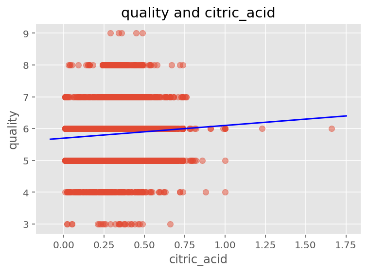

```python
def plot_line(axis, slope, intercept, **kargs):
    xmin, xmax = axis.get_xlim()
    plt.plot([xmin, xmax], [xmin*slope+intercept, xmax*slope+intercept], **kargs)


def plot_line(axis, slope, intercept, **kargs):
    xmin, xmax = axis.get_xlim()
    plt.plot([xmin, xmax], [xmin*slope+intercept, xmax*slope+intercept], **kargs)

y=winequality['citric_acid']
x=winequality['quality']

plt.scatter(winequality['citric_acid'], winequality['quality'], alpha = 0.5)
plot_line(axis = plt.gca(), slope = model_fitted.params['citric_acid'], intercept = model_fitted.params['Intercept'], color = 'blue')
plt.title('quality and citric_acid')
plt.xlabel('citric_acid')
plt.ylabel('quality')
plt.show()
```

We can observe that through the regression modelling, predicted quality in blue and the actual data combined with quality and citric_acid scattered in red, actual data near the regression line and just slightly over when quality is 6, which means that citric_acid ranged from 0-0.75 affect quality a lot while it marked as 6.

### Residuals

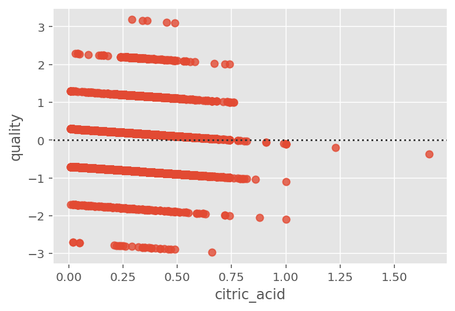

```python
sns.residplot(y, x)
plt.show()
```

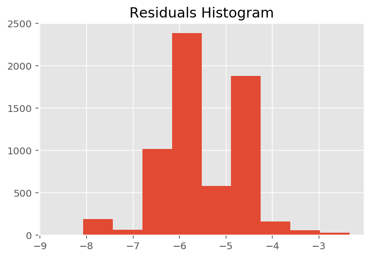

```python
residuals = y - x
plt.hist(residuals, bins = 10)
plt.title('Residuals Histogram')
plt.show()
```

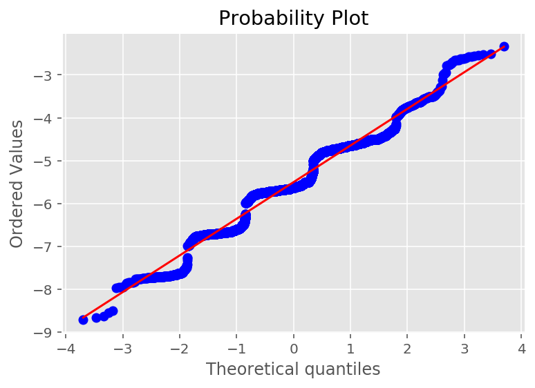

```python
sp.probplot(residuals, plot = plt)
plt.show()
```

### quality and residual sugar

```python
winequality = winequality[winequality.residual_sugar != 0.0]
formula_string = "quality ~residual_sugar"
model = sm.formula.ols(formula=formula_string, data = winequality)
model_fitted = model.fit()
print(model_fitted.summary())
```

```
                            OLS Regression Results
==============================================================================
Dep. Variable:                quality   R-squared:                       0.002
Model:                            OLS   Adj. R-squared:                  0.002
Method:                 Least Squares   F-statistic:                     13.30
Date:                Sun, 03 Nov 2019   Prob (F-statistic):           0.000267
Time:                        01:14:21   Log-Likelihood:                -8126.2
No. Observations:                6346   AIC:                         1.626e+04
Df Residuals:                    6344   BIC:                         1.627e+04
Df Model:                           1
Covariance Type:            nonrobust
==================================================================================
                     coef    std err          t      P>|t|      [0.025      0.975]
----------------------------------------------------------------------------------
Intercept          5.8750      0.017    352.152      0.000       5.842       5.908
residual_sugar    -0.0083      0.002     -3.647      0.000      -0.013      -0.004
==============================================================================
Omnibus:                       50.186   Durbin-Watson:                   1.629
Prob(Omnibus):                  0.000   Jarque-Bera (JB):               53.055
Skew:                           0.193   Prob(JB):                     3.01e-12
Kurtosis:                       3.227   Cond. No.                         11.3
==============================================================================

Warnings:
[1] Standard Errors assume that the covariance matrix of the errors is correctly specified.
```

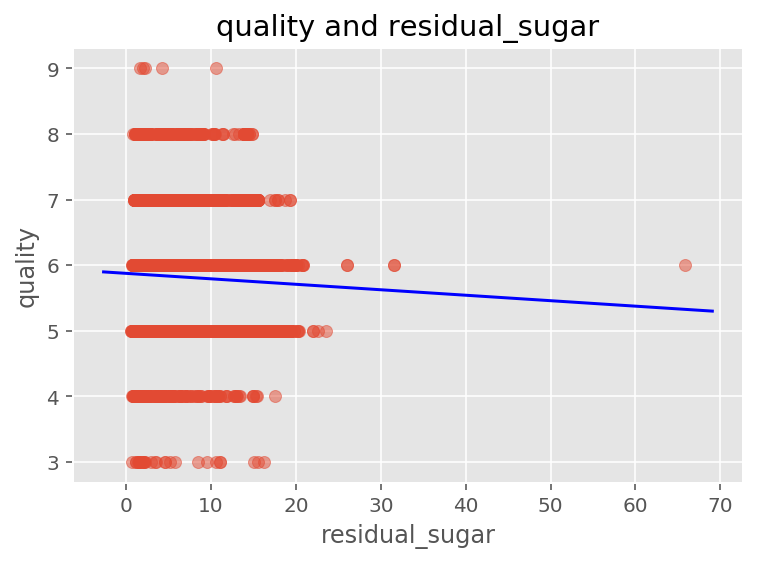

```python
def plot_line(axis, slope, intercept, **kargs):
    xmin, xmax = axis.get_xlim()
    plt.plot([xmin, xmax], [xmin*slope+intercept, xmax*slope+intercept], **kargs)


def plot_line(axis, slope, intercept, **kargs):
    xmin, xmax = axis.get_xlim()
    plt.plot([xmin, xmax], [xmin*slope+intercept, xmax*slope+intercept], **kargs)

y=winequality['residual_sugar']
x=winequality['quality']

plt.scatter(winequality['residual_sugar'], winequality['quality'], alpha = 0.5)
plot_line(axis = plt.gca(), slope = model_fitted.params['residual_sugar'], intercept = model_fitted.params['Intercept'], color = 'blue')
plt.title('quality and residual_sugar')
plt.xlabel('residual_sugar')
plt.ylabel('quality')
plt.show()
```

We can observe that through the regression modelling, predicted quality in blue and the actual data combined with quality and residual_sugar in red, actual data near the regression line and just slightly over when quality is 6, which means that residual_sugar ranged from 0-20 affect quality while it is 6.

### Residuals

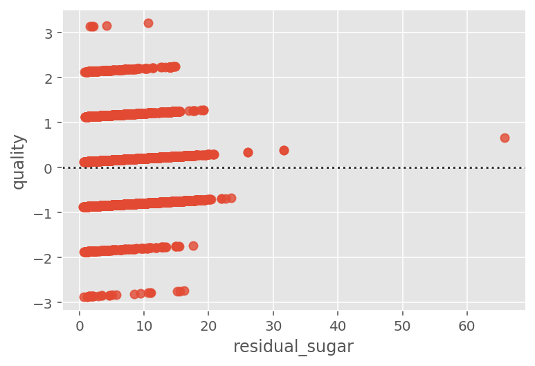

```python
sns.residplot(y, x)
plt.show()
```

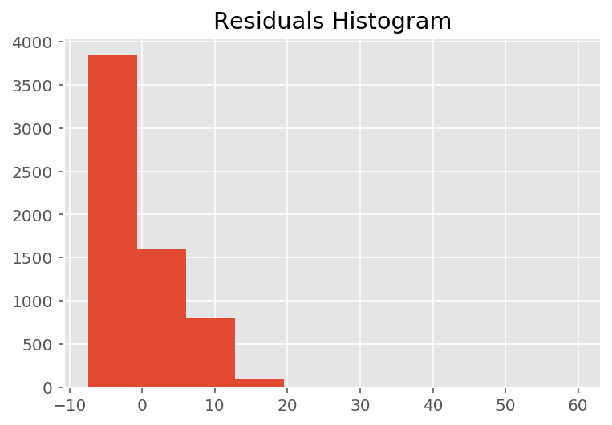

```python
residuals = y - x
plt.hist(residuals, bins = 10)
plt.title('Residuals Histogram')
plt.show()
```

residuals is not normal distributed, is right-skewed, alougth this model still can be used but not recommanded due to its meaningless.

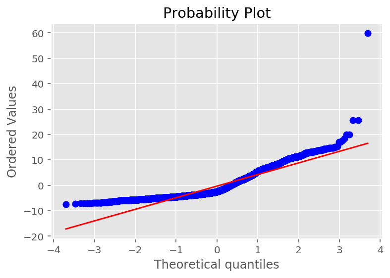

```python
sp.probplot(residuals, plot = plt)
plt.show()
```

### quality and chlorides

```python
winequality = winequality[winequality.chlorides != 0.0]
formula_string = "quality ~chlorides"
model = sm.formula.ols(formula=formula_string, data = winequality)
model_fitted = model.fit()
print(model_fitted.summary())
```

```
                            OLS Regression Results
==============================================================================
Dep. Variable:                quality   R-squared:                       0.038
Model:                            OLS   Adj. R-squared:                  0.038
Method:                 Least Squares   F-statistic:                     250.0
Date:                Sun, 03 Nov 2019   Prob (F-statistic):           2.95e-55
Time:                        01:14:23   Log-Likelihood:                -8010.2
No. Observations:                6346   AIC:                         1.602e+04
Df Residuals:                    6344   BIC:                         1.604e+04
Df Model:                           1
Covariance Type:            nonrobust
==============================================================================
                 coef    std err          t      P>|t|      [0.025      0.975]
------------------------------------------------------------------------------
Intercept      6.0986      0.020    302.687      0.000       6.059       6.138
chlorides     -4.8564      0.307    -15.811      0.000      -5.458      -4.254
==============================================================================
Omnibus:                       40.752   Durbin-Watson:                   1.661
Prob(Omnibus):                  0.000   Jarque-Bera (JB):               44.113
Skew:                           0.161   Prob(JB):                     2.64e-10
Kurtosis:                       3.251   Cond. No.                         28.7
==============================================================================

Warnings:
[1] Standard Errors assume that the covariance matrix of the errors is correctly specified.
```

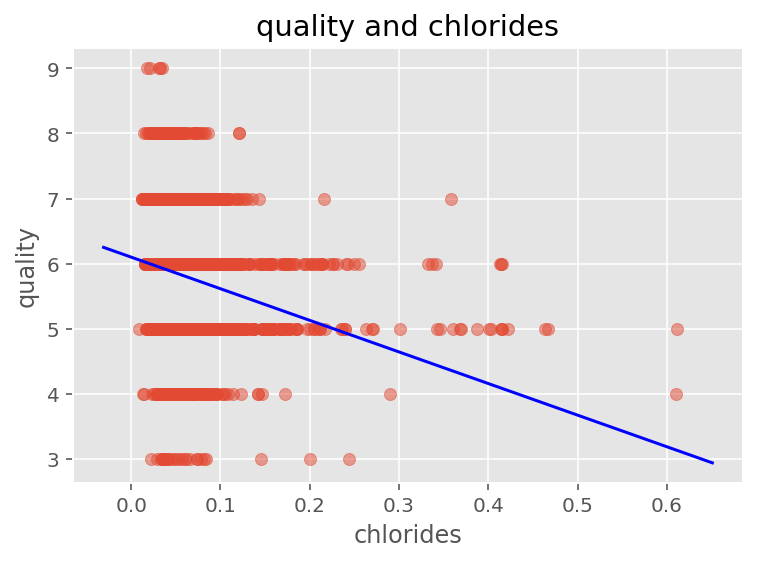

```python
def plot_line(axis, slope, intercept, **kargs):
    xmin, xmax = axis.get_xlim()
    plt.plot([xmin, xmax], [xmin*slope+intercept, xmax*slope+intercept], **kargs)


def plot_line(axis, slope, intercept, **kargs):
    xmin, xmax = axis.get_xlim()
    plt.plot([xmin, xmax], [xmin*slope+intercept, xmax*slope+intercept], **kargs)
y=winequality['chlorides']
x=winequality['quality']

plt.scatter(winequality['chlorides'], winequality['quality'], alpha = 0.5)
plot_line(axis = plt.gca(), slope = model_fitted.params['chlorides'], intercept = model_fitted.params['Intercept'], color = 'blue')
plt.title('quality and chlorides')
plt.xlabel('chlorides')
plt.ylabel('quality')
plt.show()
```

We can observe that through the regression modelling, predicted quality in blue and the actual data combined with quality and chloride scattered in red, actual data is far away from regression line, which means that chloride is not relavant to quality while it ranged from 0-0.2.

### Residuals

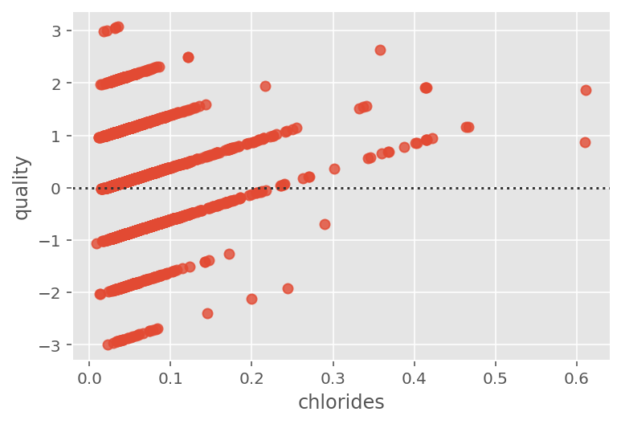

```python
sns.residplot(y, x)
plt.show()
```

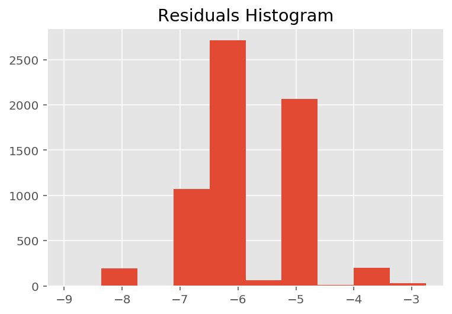

```python
residuals = y - x
plt.hist(residuals, bins = 10)
plt.title('Residuals Histogram')
plt.show()
```

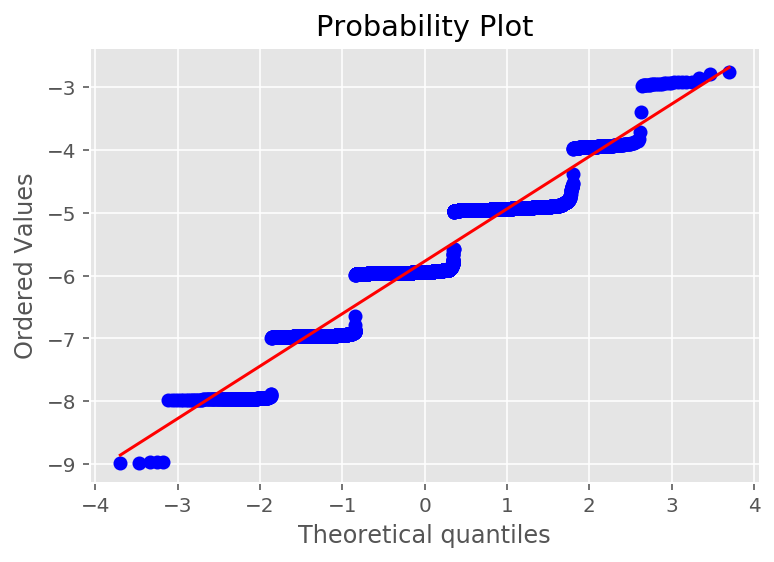

```python
sp.probplot(residuals, plot = plt)
plt.show()
```

### quality and free sulfur dioxide

```python
winequality = winequality[winequality.free_sulfur_dioxide != 0.0]
formula_string = "quality ~free_sulfur_dioxide"
model = sm.formula.ols(data = winequality,formula=formula_string)
model_fitted = model.fit()
print(model_fitted.summary())
```

```
                            OLS Regression Results
==============================================================================
Dep. Variable:                quality   R-squared:                       0.002
Model:                            OLS   Adj. R-squared:                  0.002
Method:                 Least Squares   F-statistic:                     13.46
Date:                Sun, 03 Nov 2019   Prob (F-statistic):           0.000246
Time:                        01:14:25   Log-Likelihood:                -8126.1
No. Observations:                6346   AIC:                         1.626e+04
Df Residuals:                    6344   BIC:                         1.627e+04
Df Model:                           1
Covariance Type:            nonrobust
=======================================================================================
                          coef    std err          t      P>|t|      [0.025      0.975]
---------------------------------------------------------------------------------------
Intercept               5.7593      0.022    262.539      0.000       5.716       5.802
free_sulfur_dioxide     0.0023      0.001      3.669      0.000       0.001       0.003
==============================================================================
Omnibus:                       52.829   Durbin-Watson:                   1.646
Prob(Omnibus):                  0.000   Jarque-Bera (JB):               55.425
Skew:                           0.203   Prob(JB):                     9.22e-13
Kurtosis:                       3.213   Cond. No.                         71.4
==============================================================================

Warnings:
[1] Standard Errors assume that the covariance matrix of the errors is correctly specified.
```

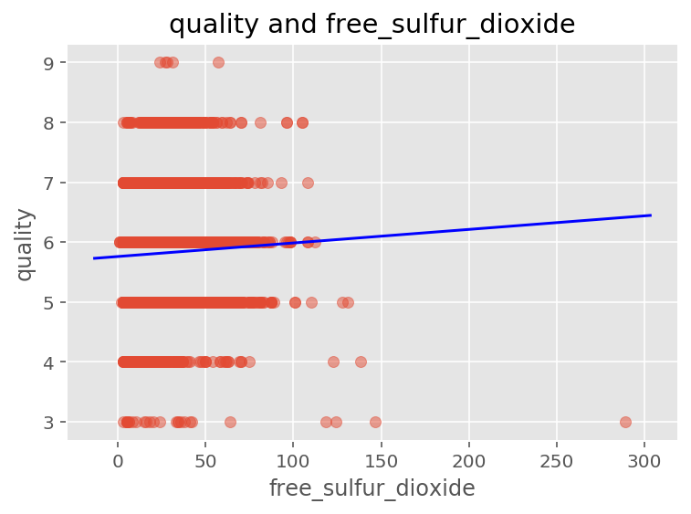

```python
def plot_line(axis, slope, intercept, **kargs):
    xmin, xmax = axis.get_xlim()
    plt.plot([xmin, xmax], [xmin*slope+intercept, xmax*slope+intercept], **kargs)


def plot_line(axis, slope, intercept, **kargs):
    xmin, xmax = axis.get_xlim()
    plt.plot([xmin, xmax], [xmin*slope+intercept, xmax*slope+intercept], **kargs)

y=winequality['free_sulfur_dioxide']
x=winequality['quality']

plt.scatter(winequality['free_sulfur_dioxide'], winequality['quality'], alpha = 0.5)
plot_line(axis = plt.gca(), slope = model_fitted.params['free_sulfur_dioxide'], intercept = model_fitted.params['Intercept'], color = 'blue')
plt.title('quality and free_sulfur_dioxide')
plt.xlabel('free_sulfur_dioxide')
plt.ylabel('quality')
plt.show()
```

We can observe that through the regression modelling, predicted quality in blue and the actual data combined with quality and free_sulfur_dioxide in red, actual data near the regression line and just slightly over when quality is 6, which means that free_sulfur_dioxide ranged from 0-90 affect quality in some degree.

### Residuals

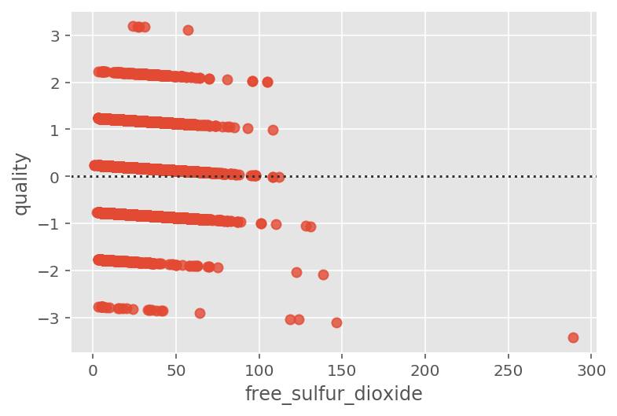

```python
sns.residplot(y, x)
plt.show()
```

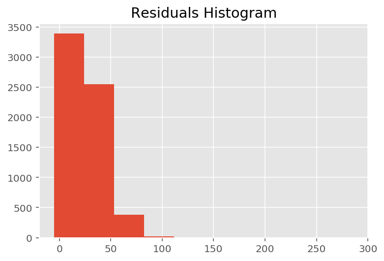

```python
residuals = y - x
plt.hist(residuals, bins = 10)
plt.title('Residuals Histogram')
plt.show()
```

residuals is not normal distributed, is right-skewed, alougth this model still can be used but not recommanded due to its meaningless.

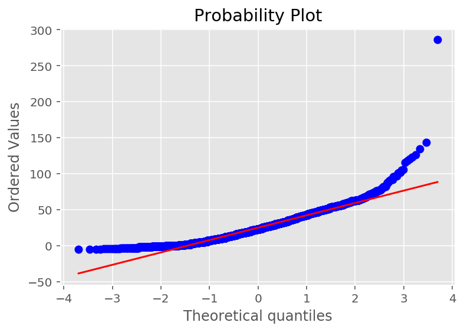

```python
sp.probplot(residuals, plot = plt)
plt.show()
```

### quality and total sulfur dioxide

```python
winequality = winequality[winequality.total_sulfur_dioxide != 0.0]
formula_string = "quality ~total_sulfur_dioxide"
model = sm.formula.ols(formula=formula_string, data = winequality)
model_fitted = model.fit()
print(model_fitted.summary())
```

```
                            OLS Regression Results
==============================================================================
Dep. Variable:                quality   R-squared:                       0.004
Model:                            OLS   Adj. R-squared:                  0.003
Method:                 Least Squares   F-statistic:                     22.94
Date:                Sun, 03 Nov 2019   Prob (F-statistic):           1.71e-06
Time:                        01:14:27   Log-Likelihood:                -8121.4
No. Observations:                6346   AIC:                         1.625e+04
Df Residuals:                    6344   BIC:                         1.626e+04
Df Model:                           1
Covariance Type:            nonrobust
========================================================================================
                           coef    std err          t      P>|t|      [0.025      0.975]
----------------------------------------------------------------------------------------
Intercept                5.9393      0.025    233.082      0.000       5.889       5.989
total_sulfur_dioxide    -0.0009      0.000     -4.790      0.000      -0.001      -0.001
==============================================================================
Omnibus:                       52.176   Durbin-Watson:                   1.621
Prob(Omnibus):                  0.000   Jarque-Bera (JB):               55.324
Skew:                           0.196   Prob(JB):                     9.70e-13
Kurtosis:                       3.234   Cond. No.                         303.
==============================================================================

Warnings:
[1] Standard Errors assume that the covariance matrix of the errors is correctly specified.
```

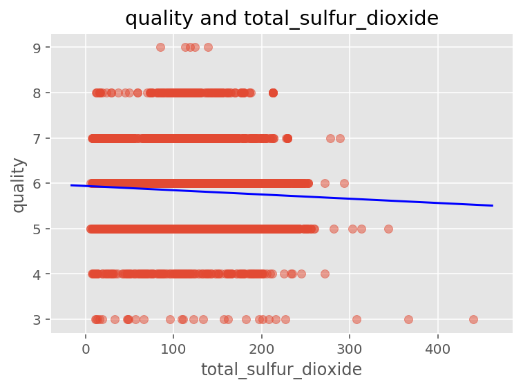

```python
def plot_line(axis, slope, intercept, **kargs):
    xmin, xmax = axis.get_xlim()
    plt.plot([xmin, xmax], [xmin*slope+intercept, xmax*slope+intercept], **kargs)


def plot_line(axis, slope, intercept, **kargs):
    xmin, xmax = axis.get_xlim()
    plt.plot([xmin, xmax], [xmin*slope+intercept, xmax*slope+intercept], **kargs)


y=winequality['total_sulfur_dioxide']
x=winequality['quality']
plt.scatter(winequality['total_sulfur_dioxide'], winequality['quality'], alpha = 0.5)
plot_line(axis = plt.gca(), slope = model_fitted.params['total_sulfur_dioxide'], intercept = model_fitted.params['Intercept'], color = 'blue')
plt.title('quality and total_sulfur_dioxide')
plt.xlabel('total_sulfur_dioxide')
plt.ylabel('quality')
plt.show()
```

We can observe that through the regression modelling, predicted quality in blue and the actual data combined with quality and total_sulfur_dioxide in red, actual data near the regression line and just slightly over when quality is 6, which means that total_sulfur_dioxide ranged from 0-250 affect quality when mostly marked as 6.